# R Coding Lab Part 4

**Complete the following lab as a group. This document should exist in your GitHub repo while you”re working on it. Your code should be heavily commented so someone reading your code can follow along easily. See the first code snippet below for an example of commented code.**

**Here”s the catch: For any given problem, the person writing the code should not be the person commenting that code, and every person must both code AND comment at least one problem in this lab (you decide how to split the work). This will involve lots of pushing and pulling through Git, and you may have to resolve conflicts if you”re not careful! Refer to last Thursday”s class notes for details on conflict resolution.**

**ALSO, all plots generated should have labeled axes, titles, and legends when appropriate. Don”t forget units of measurement! Make sure these plots could be interpreted by your client.**

These problems were adapted from **Cleaning Data for Effective Data Science** by David Mertz

# Dealing With Outliers

The Michelson–Morley experiment was an attempt in the late 19th century to detect the existence of the luminiferous aether, a widely assumed medium that would carry light waves. This was the most famous “failed experiment” in the history of physics in that it did not detect what it was looking for—something we now know not to exist at all.

The general idea was to measure the speed of light under different orientations of the equipment relative to the direction of movement of the Earth, since relative movement of the ether medium would add or subtract from the speed of the wave. Yes, it does not work that way under the theory of relativity, but it was a reasonable guess 150 years ago.

Apart from the physics questions, the dataset derived by the Michelson–Morley experiment is widely available, including the sample given in `morley.dat`. The specific numbers in this data are measurements of the speed of light in km/s with a zero point of 299,000. So, for example, the mean measurement in experiment 1 was 299,909 km/s (you can check this when you load the data).

1. Using R to identify the outliers first within each setup (defined by the `Expt` number) and then within the data collection as a whole. The hope in the original experiment was that each setup would show a significant difference in central tendency. We did not cover confidence levels and null hypotheses, so simply create visualization(s) that aids you in gaining insight into how much apparent difference exists between the several setups.

```r
library(dplyr)
```

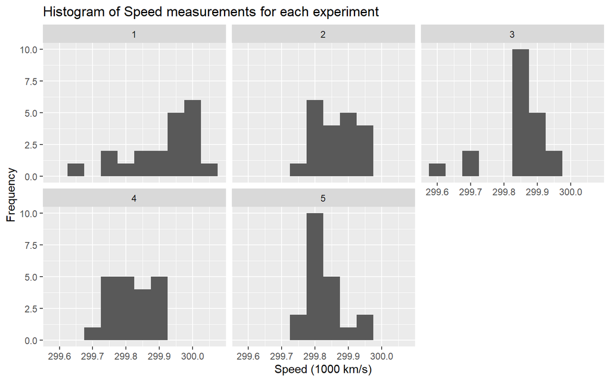

```r
library(ggplot2)

# Load data
df <- read.csv("morley.dat", sep = "")

# Uncentering speed data
df <- df %>%
    mutate(Speed = Speed + 299000)

# Calculate the Zscore of speed by experiment
df <- df %>%
    group_by(Expt) %>%
    mutate(expt_mean = mean(Speed)) %>%
    mutate(expt_sd = sd(Speed)) %>%
    mutate(zscore = ( Speed - expt_mean) / expt_sd )

# Plot histogram of recorded speed (in thousands km/s) for each experiment
ggplot(
    data = df,
    aes(
        x = Speed / 1000
        )
    ) +
    xlab("Speed (1000 km/s)") +
    ylab("Frequency") +
    geom_histogram(bins = 10) +
    facet_wrap(vars(Expt)) +
    ggtitle("Histogram of Speed measurements for each experiment")
```

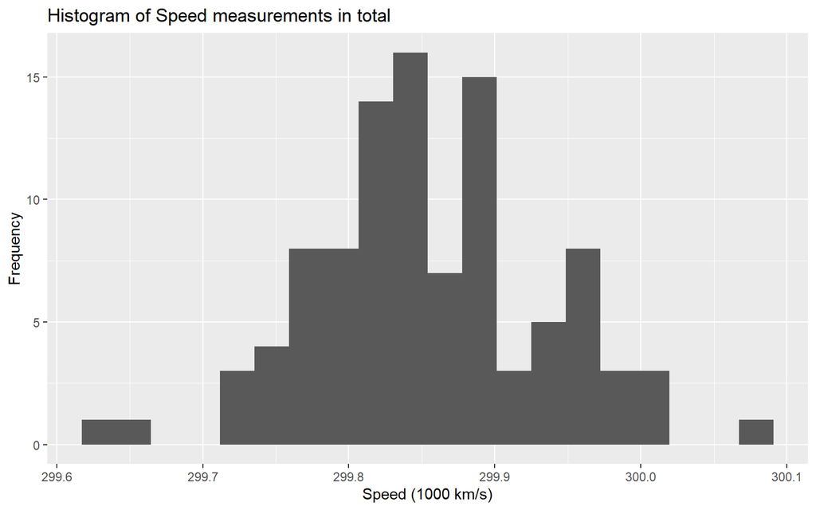

```r
# Plot histogram of recorded speed for all experiments
ggplot(
    data = df,
    aes(
        x = Speed / 1000
        )
    ) +
    xlab("Speed (1000 km/s)") +
    ylab("Frequency") +
    geom_histogram(bins = 20) +
    ggtitle("Histogram of Speed measurements in total")
```

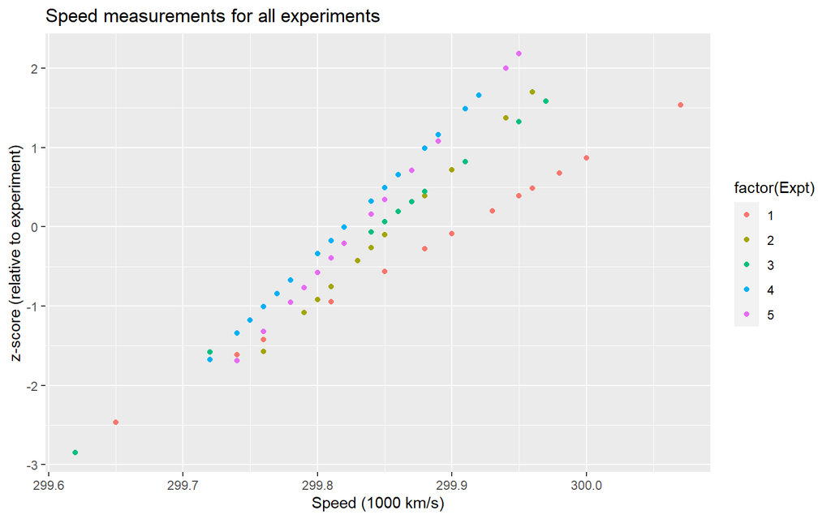

```r
# See the spread of data experiment
ggplot(data = df) +
    geom_point(
    aes(
        x = Speed / 1000,
        y = zscore,
        color = factor(Expt)
        )
    ) +
    xlab("Speed (1000 km/s)") +
    ylab("z-score (relative to experiment)") +
    ggtitle("Speed measurements for all experiments")
```

2. If you discard the outliers within each setup, are the differences between setups increased or decreased? Answer with either a visualization or by looking at statistics on the reduced groups.

[output not shown]

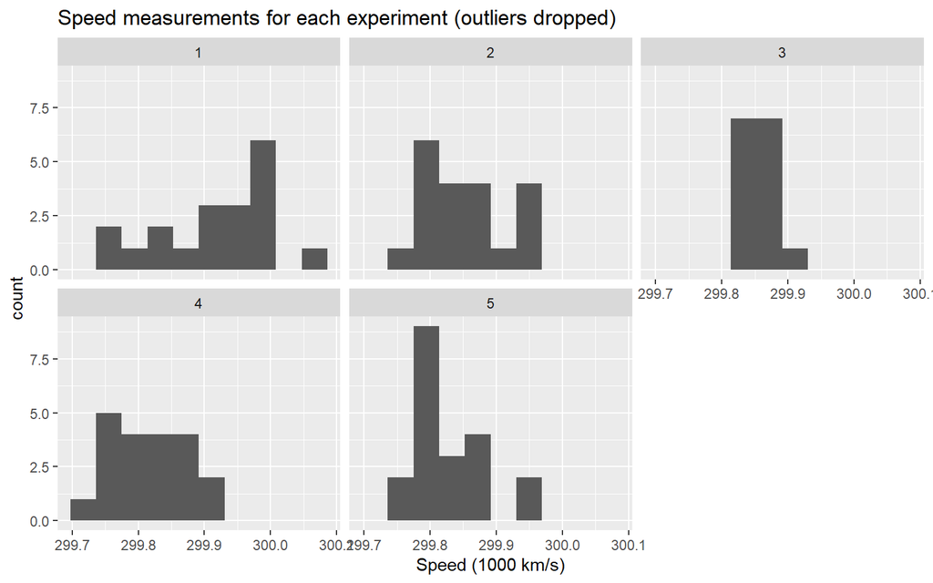

```r
# initialize variables for IQR method
df <- df %>%
    mutate(Q1 = 0) %>%
    mutate(Q3 = 0) %>%
    mutate(IQR = 0)

# Detect outliers using IQR method
for (i in 1:5) {
  df$Q1[df$Expt == i] <- quantile(df$Speed[df$Expt == i], .25)
  df$Q3[df$Expt == i] <- quantile(df$Speed[df$Expt == i], .75)
  df$IQR[df$Expt == i] <- IQR(df$Speed[df$Expt == i])
}

# Only keep rows in dataframe that have values within 1.5*IQR of Q1 and Q3
cleaned <- subset(df, Speed> (Q1 - 1.5*IQR) & Speed< (Q3 + 1.5*IQR))

# Histogram of speed measurement after dropping outliers, by experiment
ggplot(
    data = cleaned,
    aes(
        x = Speed / 1000
        )
    ) +
    xlab("Speed (1000 km/s)") +
    geom_histogram(bins = 10) +
    facet_wrap(vars(Expt)) +
    ggtitle("Speed measurements for each experiment (outliers dropped)")
```

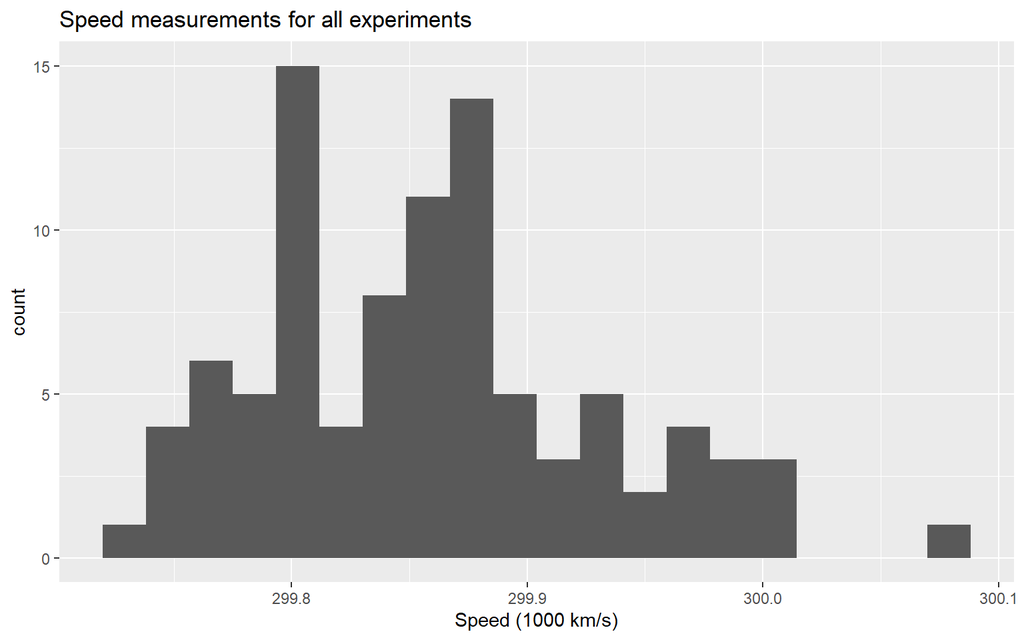

```r
# Histogram of speed measurement after dropping outliers
ggplot(
    data = cleaned,
    aes(
        x = Speed / 1000
        )
    ) +
    xlab("Speed (1000 km/s)") +
    geom_histogram(bins = 20) +
    ggtitle("Speed measurements for all experiments")
```

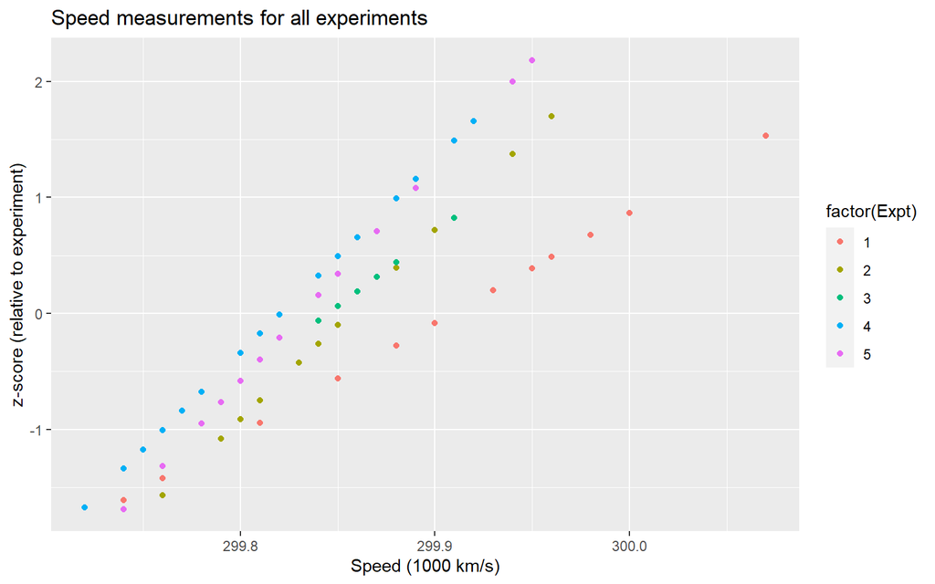

```r
# scatter plot of measurements vs the z-score relative to the experiment
ggplot(data = cleaned) +
    geom_point(
    aes(
        x = Speed / 1000,
        y = zscore,
        color = factor(Expt)
        )
    ) +
    xlab("Speed (1000 km/s)") +
    ylab("z-score (relative to experiment)") +
    ggtitle("Speed measurements for all experiments")
```

```r
# display statistics of raw and cleaned data (remove redundant info)
df <- df %>%
    select(
        -zscore,
        -expt_mean,
        -expt_sd
        )

cleaned <- cleaned %>%
    select(
        -zscore,
        -expt_mean,
        -expt_sd
        )

summary(df)
```

```
##       Expt        Run            Speed              Q1               Q3
##  Min.   :1   Min.   : 1.00   Min.   :299620   Min.   :299768   Min.   :299865
##  1st Qu.:2   1st Qu.: 5.75   1st Qu.:299808   1st Qu.:299800   1st Qu.:299870
##  Median :3   Median :10.50   Median :299850   Median :299808   Median :299880
##  Mean   :3   Mean   :10.50   Mean   :299852   Mean   :299813   Mean   :299896
##  3rd Qu.:4   3rd Qu.:15.25   3rd Qu.:299893   3rd Qu.:299840   3rd Qu.:299885
##  Max.   :5   Max.   :20.00   Max.   :300070   Max.   :299850   Max.   :299980
##       IQR
##  Min.   : 40.0
##  1st Qu.: 62.5
##  Median : 85.0
##  Mean   : 83.0
##  3rd Qu.: 97.5
##  Max.   :130.0
```

```r
summary(cleaned)
```

```
##       Expt            Run            Speed              Q1
##  Min.   :1.000   Min.   : 1.00   Min.   :299720   Min.   :299768
##  1st Qu.:2.000   1st Qu.: 5.25   1st Qu.:299810   1st Qu.:299800
##  Median :3.000   Median :11.00   Median :299850   Median :299808
##  Mean   :3.021   Mean   :10.63   Mean   :299858   Mean   :299811
##  3rd Qu.:4.000   3rd Qu.:16.00   3rd Qu.:299890   3rd Qu.:299840
##  Max.   :5.000   Max.   :20.00   Max.   :300070   Max.   :299850
##        Q3              IQR
##  Min.   :299865   Min.   : 40.00
##  1st Qu.:299870   1st Qu.: 62.50
##  Median :299880   Median : 85.00
##  Mean   :299896   Mean   : 84.79
##  3rd Qu.:299885   3rd Qu.: 97.50
##  Max.   :299980   Max.   :130.00
```

```r
# display some more statistics
df %>%
  group_by(Expt) %>%
  summarise(
    n = n(),
    min = min(Speed),
    max = max(Speed),
    mean = mean(Speed),
    sd = sd(Speed)
  )
```

```
## # A tibble: 5 × 6
##    Expt     n    min    max    mean    sd
##   <int> <int>  <dbl>  <dbl>   <dbl> <dbl>
## 1     1    20 299650 300070 299909  105.
## 2     2    20 299760 299960 299856   61.2
## 3     3    20 299620 299970 299845   79.1
## 4     4    20 299720 299920 299820.  60.0
## 5     5    20 299740 299950 299832.  54.2
```

```r
cleaned %>%
  group_by(Expt) %>%
  summarise(
    n = n(),
    min = min(Speed),
    max = max(Speed),
    mean = mean(Speed),
    sd = sd(Speed)
  )
```

```
## # A tibble: 5 × 6
##    Expt     n    min    max    mean    sd
##   <int> <int>  <dbl>  <dbl>   <dbl> <dbl>
## 1     1    19 299740 300070 299923.  87.7
## 2     2    20 299760 299960 299856   61.2
## 3     3    15 299840 299910 299861.  21.3
## 4     4    20 299720 299920 299820.  60.0
## 5     5    20 299740 299950 299832.  54.2
```

# Mispelled Names

Our data set `humans-names.csv` contains 25,000 height and weight measurements. Each row has a person’s first name pulled from the US Social Security Agency list of common first names over the last century.

Unfortunately, our hypothetical data collectors for this dataset are simply terrible typists, and they make typos when entering names with alarming frequency. There are some number of intended names in this dataset, but quite a few simple miscodings of those names as well. Your goal is to clean up these mispelled names.

1. Identify every genuine name and correct all the misspelled ones to the correct canonical spelling. Use all the data wrangling tools you”d like (e.g. `dplyr` functions), but make sure you”re checking each reassignment to make sure the names get classified correctly. You”ll fully automate this process later. It is probably reasonable to assume that rare spellings are typos, at least if they are also relatively similar to common spellings. Hint: There are a number of ways to measure the similarity of strings and that provide a clue as to likely typos. One general class of approach is in terms of edit distance between strings, which describes how many edititing operations need to be done to tranform one string into another. The R package `stringdist` provides Damerau–Levenshtein, Hamming, Levenshtein, and optimal string alignment as measures of edit distance. Keep in mind that sometimes multiple legitimate names are actually close to each other in terms of similarity measures (Dan VS Don, Jacob VS Jakob, etc). If you want to use `stringdist` for this problem, start by looking at the functions `stringdist()` and `stringdistmatrix()`.

```r
library(stringdist)
library(readxl)
library(dplyr)
library(stringr)

# load data set
humans_names <- read.csv("humans-names.csv")

# tally the unique names and create a new data set ordered by frequency
unique_names = humans_names %>%
  select(Name) %>%
  count(Name) %>%
  arrange(n)

# observe that names appearing n<=5 are likely to be errors
unique_names$genuine[unique_names$n > 5] <- 1
unique_names$genuine[unique_names$n <= 5] <- 0

# partition the data set into (likely) genuine and error names
genuine <- unique_names[unique_names$genuine == 1, ]
error <- unique_names[unique_names$genuine == 0, ]

# compute the distance matrix between each distinct pair of names in the
# stringdist metric
resultflmatrix <- stringdistmatrix(error$Name, genuine$Name, method = 'dl')
resultdf <- data.frame(resultflmatrix)
resultdf$error_name <- error$Name

# It's likely that mispelled names have distant ={1,2} to correct ones
resultdf <- resultdf %>% mutate(corrected = case_when(
  stringdist("Barbara", error_name, method='dl')<3 ~ "Barbara",
  stringdist("David", error_name, method='dl')<3 ~ "David",
  stringdist("Elizabeth", error_name, method='dl')<3 ~ "Elizabeth",
  stringdist("James", error_name, method='dl')<3 ~ "James",
  stringdist("Jennifer", error_name, method='dl')<3 ~ "Jennifer",
  stringdist("Jessica", error_name, method='dl')<3 ~ "Jessica",
  stringdist("John", error_name, method='dl')<3 & str_detect(error_name,"h") ~ "John",
  stringdist("Jon", error_name, method='dl') <3 ~ "Jon",
  stringdist("Joseph", error_name, method='dl')<3 ~ "Joseph",
  stringdist("Linda", error_name, method='dl')<3 ~ "Linda",
  stringdist("Marie", error_name, method='dl')<3 ~ "Marie",
  stringdist("Mary", error_name, method='dl')<3 ~ "Mary",
  stringdist("Michael", error_name, method='dl')<3 ~ "Michael",
  stringdist("Patricia", error_name, method='dl')<3 ~ "Patricia",
  stringdist("Richard", error_name, method='dl')<3 ~ "Richard",
  stringdist("Robert", error_name, method='dl')<3 ~ "Robert",
  stringdist("Susan", error_name, method='dl')<3 ~ "Susan",
  stringdist("William", error_name, method='dl')<3 ~ "William",
))

# check if any mispelled names left uncorrected
resultdf %>%
  summarise_all(~sum(is.na(.)))
```

```
##   X1 X2 X3 X4 X5 X6 X7 X8 X9 X10 X11 X12 X13 X14 X15 X16 X17 X18 error_name
## 1  0  0  0  0  0  0  0  0  0   0   0   0   0   0   0   0   0   0          0
##   corrected
## 1         0
```

2. For each of the genuine names identified in (1), produce a histogram showing the distribution of Damerau–Levenshtein distances from the genuine name to the misclassified data. Make sure distances from genuine names to other genuine names are not included in these distributions. Arrange all of the histograms into one figure write a short interpretation of it intended for a non-statistician client.

```
Below we see plots of the names that were corrected. For each incorrect name, we
can measure the "distance" to the correct name by counting the number of
incorrect letters. We found that this distance was at most two incorrect letters
in this data set. For each genuine name, we count the number of incorrect names
that were distance either one or two correct letters.
```

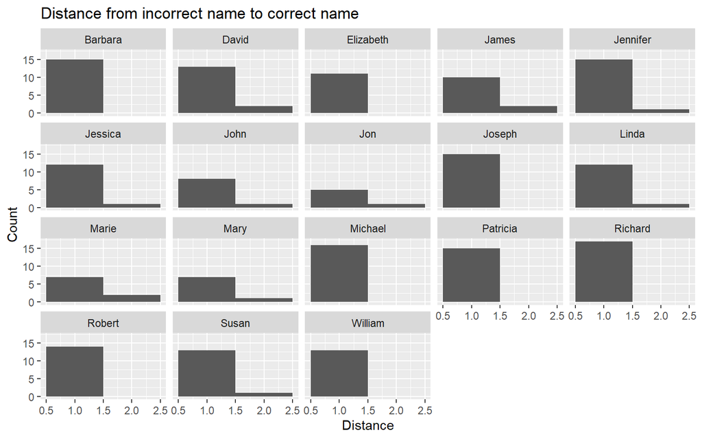

```r
resultdf <- resultdf %>%
    mutate(distance_to_correct = stringdist(error_name, corrected))

ggplot(
    data = resultdf,
    aes(
        x = distance_to_correct,
        group = corrected
        )
    ) +
    xlab("Distance") +
    ylab("Count") +
    geom_histogram(bins = 2) +
    ggtitle("Distance from incorrect name to correct name") +
    facet_wrap(~corrected)
```

3. Write code that reclassifies names similar to problem (1), but fully automated. You should end up with a function that takes the original data set and returns a cleaned version. Compare this cleaned data frame to the one from problem (1) and quantify the accuracy (i.e. what proportion of rows match?). Make sure your automated process achieves 90%, but shoot for higher if possible!

```r
cleanname <-function(df) {

  # count the appearance of each unique names
  unique_names = df %>%
  select(Name) %>%
  count(Name) %>%
  arrange(n)

  # observe that names appearing n<=5 are likely to be errors
  unique_names$genuine[unique_names$n > 5] <- 1
  unique_names$genuine[unique_names$n <= 5] <- 0

  # partition the data set into (likely) genuine and error names
  genuine <- unique_names[unique_names$genuine == 1, ]
  error <- unique_names[unique_names$genuine == 0, ]

  # compute the distance matrix between each distinct pair of names in the stringdist metric
  resultflmatrix <- stringdistmatrix(error$Name, genuine$Name, method = 'dl')
  resultdf <- data.frame(resultflmatrix)
  n_genuine <- ncol(resultdf)
  resultdf$error_name <- error$Name

  # search for a closest neighbor in this metric for each name
  resultdf[c("min")] <- apply(
      resultdf[c(1:n_genuine)], 1, function(x) c(min(x))
      )
  resultdf[c("min_index")] <- apply(
      resultdf[c(1:n_genuine)], 1, function(x) c(which.min(x))
      )

  # get the correct name by index and plug in cleaning result dataframe
  resultdf$corrected <- genuine$Name[resultdf$min_index]

  # merge the cleaning result with the original dataset and return
  resultdf <- resultdf %>% select(error_name, corrected)
  humans_names_cleaned <- humans_names %>% left_join(resultdf, by = c("Name" = "error_name"))
  humans_names_cleaned <- humans_names_cleaned %>%
    mutate(corrected = coalesce(corrected,Name))
  return(list(sum(resultdf$corrected==m_resultdf$corrected), humans_names_cleaned))
}

humans_names_cleaned <- cleanname(humans_names)[[2]]
head(humans_names_cleaned)
```

```
##      Name   Height   Weight corrected
## 1   James 167.0896 64.80622     James
## 2   David 181.6486 78.28153     David
## 3 Barbara 176.2728 87.76772   Barbara
## 4    John 173.2702 81.63567      John
## 5 Michael 172.1810 82.76079   Michael
## 6 William 174.4925 70.71940   William
```

```r
print(cleanname(humans_names)[[1]]/231) # match 97% with the manual method.
```

```
## [1] 0.974026
```